# Assignment 2

Group 5

September 18, 2019

The following table shows the list of variables and their initial data type classification.

|  | Variable Type |
| --- | --- |
| X | integer |
| id | integer |
| member_id | integer |
| loan_amnt | integer |
| funded_amnt | integer |
| funded_amnt_inv | numeric |
| term | factor |
| int_rate | numeric |
| installment | numeric |
| emp_length | factor |
| home_ownership | factor |
| annual_inc | numeric |
| verification_status | factor |
| issue_d | factor |
| loan_status | factor |
| purpose | factor |
| zip_code | factor |
| addr_state | factor |
| dti | numeric |
| delinq_2yrs | integer |
| earliest_cr_line | factor |
| inq_last_6mths | integer |
| mths_since_last_delinq | integer |
| open_acc | integer |
| pub_rec | integer |
| revol_bal | integer |
| revol_util | factor |
| total_acc | integer |
| total_pymnt | numeric |
| total_pymnt_inv | numeric |
| total_rec_prncp | numeric |
| total_rec_int | numeric |
| last_pymnt_d | factor |
| last_pymnt_amnt | numeric |
| next_pymnt_d | factor |
| last_credit_pull_d | factor |
| repay_fail | integer |

Investigate the dataset dimensions to understand the number of variables and observations.

```
## [1] 38480    37
```

We can see the initial dataset contains 38480 observations and 37 variables. By using the data dictionary provided for the variables `LCDataDictionary.xls`, we can assign correct data types for each and begin data cleansing activities to arrive at a final set of variables to continue analysis.

# Data Cleansing

Data cleansing activities for this project will include:

1. Initial removal of unnecessary variables
2. Correcting data types
3. Dealing with missing values

## Initial removal of unnecessary variables.

Initially, the data dictionary was consulted and each variable’s importance was discussed in terms of its value to the model. Here it is important to keep in mind that our objective is to create a predictive model that will be able to determine whether or not a new customer will fail to pay back the loan issued by the bank. In this context, only variables available at loan application will be considered. Consequently, the following variables were considered unnecessary, with justification shown below:

*id =* unique identifier with no predictive power *member_id =* unique identifier for borrower with no predictive power *x =* unique row identifier with no predictive power *last_pymnt_d =* not applicable to outcome from business perspective *last_pymnt_amnt =* not applicable to outcome from business perspective *next_pymnt_d =* not applicable to outcome from business perspective *total_pymnt_inv =* not applicable to outcome from business perspective *zip_code =* not special evaluation

These variables were removed resulting in a dataset of dimensions:

```
## [1] 38480    29
```

The new data set now contains 38480 observations and 29 variables.

## Correcting Data types

This section will focus on the data types of each variable. The variable `revol_util` contains a percent (%) character which should be removed.

Then, we convert each variable to the class it should be for our visualisation and later analysis.

Using the newly created value `months_with_cr_line` instead of the following date-related variables:

- `issue_d`
- `earliest_cr_line`
- `last_credit_pull_d`

which were removed from the data set.

It is noted that there were some missing values introduced by coercion however these will be addressed in a separate section. The new classes are:

|  | Variable Type |
| --- | --- |
| loan_amnt | numeric |
| funded_amnt | numeric |
| funded_amnt_inv | numeric |
| term.1 | ordered |
| term.2 | factor |
| int_rate | numeric |
| installment | numeric |
| emp_length | factor |
| home_ownership | factor |
| annual_inc | numeric |
| verification_status | factor |
| loan_status | factor |
| purpose | factor |
| addr_state | factor |
| dti | numeric |
| delinq_2yrs | integer |
| inq_last_6mths | integer |
| mths_since_last_delinq | numeric |
| open_acc | integer |
| pub_rec | integer |
| revol_bal | numeric |
| revol_util | numeric |
| total_acc | integer |
| total_pymnt | numeric |
| total_rec_prncp | numeric |
| total_rec_int | numeric |
| repay_fail | integer |
| months_with_cr_line | numeric |

## Dealing with missing values

To gain an appreciation for the number of missing values across the data set, we investigate the total number per row to determine if some observations are salvageable by imputation or not. Those that aren’t will be removed entirely.

| na_count | Freq |
| --- | --- |
| 0 | 14094 |
| 1 | 24343 |
| 2 | 42 |
| 15 | 1 |

The table above shows the number of rows (right hand side) that contain missing values and the number of missing values (left hand side). We can see the first entry indicates that there are 14,094 rows with no missing values (0). The last entry shows there is 1 row with 15 missing values. Where a row contains many missing values, its usefulness is limited. Consequently, the row containing 15 missing values will be removed.

Next, we’ll check the same thing but for columns. Where there are many missing values for a column, the column must be imputed with sensible values or removed if there are simply too many.

|  | Variables | Frequencies |
| --- | --- | --- |
| 17 | mths_since_last_delinq | 24362 |
| 21 | revol_util | 59 |
| 20 | revol_bal | 3 |
| 9 | annual_inc | 1 |
| 1 | loan_amnt | 0 |
| 2 | funded_amnt | 0 |
| 3 | funded_amnt_inv | 0 |
| 4 | term | 0 |
| 5 | int_rate | 0 |
| 6 | installment | 0 |
| 7 | emp_length | 0 |
| 8 | home_ownership | 0 |
| 10 | verification_status | 0 |
| 11 | loan_status | 0 |
| 12 | purpose | 0 |
| 13 | addr_state | 0 |
| 14 | dti | 0 |
| 15 | delinq_2yrs | 0 |
| 16 | inq_last_6mths | 0 |
| 18 | open_acc | 0 |
| 19 | pub_rec | 0 |
| 22 | total_acc | 0 |
| 23 | total_pymnt | 0 |
| 24 | total_rec_prncp | 0 |
| 25 | total_rec_int | 0 |
| 26 | repay_fail | 0 |
| 27 | months_with_cr_line | 0 |

The columns with missing values will be handled as described below.

*mths_since_last_delinq:* The variable will be grouped into four categories: low (up to 40 months), medium (40-80 months), high (81-120 months) and very_high (+120 months). Missing values will be interpreted as “never having been delinquent” and will receive a value of 121, placing it in the “very_high” category. Missing values will be assigned the value “not provided”.

*revol_util:* This variable should be imputed with the median value.

*revol_bal:* This variable should be imputed with the median value.

*annual_inc:* This variable should be imputed with the median value.

|  | x |
| --- | --- |
| annual_inc | 58650.0 |
| revol_bal | 8840.0 |
| revol_util | 49.6 |

Having fixed all the missing values, we derive a final data set to begin exploratory data analysis. One last look at the dataset dimensions shows it contains 38478 observations and 27 variables.

```
## [1] 38478    27
```

Lastly, we export this for convenience so it can be imported into future analysis documents.

```
## Writing...
```

```
## Completed.
```

```r
# Load data frame from previously saved data object
load("defaults_data.rda")
```

Perform a quick class check on the data set.

|  | Variable Type |
| --- | --- |
| loan_amnt | numeric |
| funded_amnt | numeric |
| funded_amnt_inv | numeric |
| term.1 | ordered |
| term.2 | factor |
| int_rate | numeric |
| installment | numeric |
| emp_length | factor |
| home_ownership | factor |
| annual_inc | numeric |
| verification_status | factor |
| loan_status | factor |
| purpose | factor |
| addr_state | factor |
| dti | numeric |
| delinq_2yrs | integer |
| inq_last_6mths | integer |
| mths_since_last_delinq | factor |
| open_acc | integer |
| pub_rec | integer |
| revol_bal | numeric |
| revol_util | numeric |
| total_acc | integer |
| total_pymnt | numeric |
| total_rec_prncp | numeric |
| total_rec_int | numeric |
| repay_fail | integer |
| months_with_cr_line | numeric |

# Exploratory Data Analysis

## Analysis of continuous variables

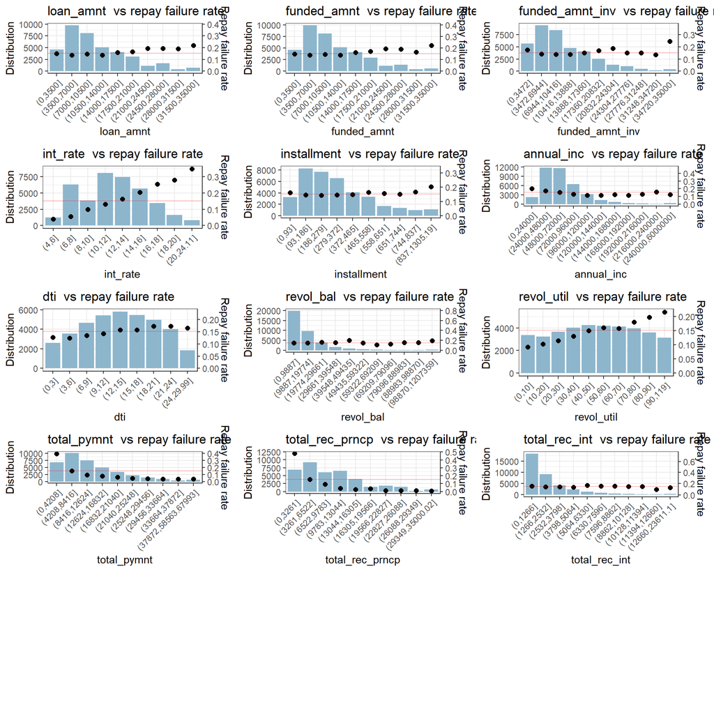

Now that we have an initial understanding of repayment failure rates for continuous variables, any correlation between them should be explored. We aim to eliminate highly correlated variables from our final feature list so that we are not unnecessarily including variables with similar predictive power in the model. A correlation matrix showing the strength (magnitude) and direction (negative / positive) for each variable is included in the following image:

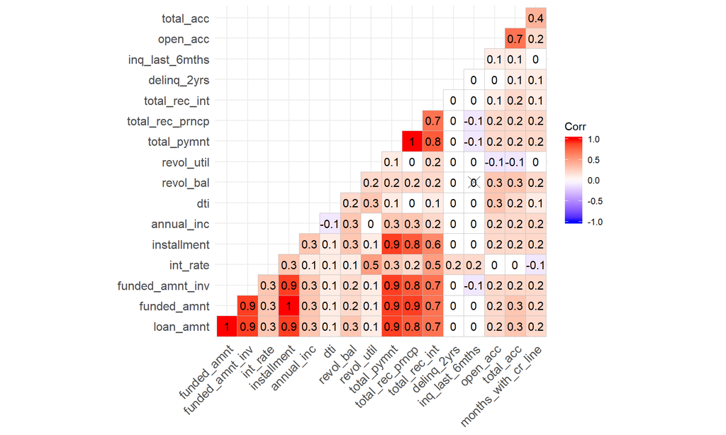

The image shows that there are some variables with a strong correlation. For instance, `loan_amnt` is highly correlated with six other variables: `funded_amnt`, `funded_amt_inv`, `installment`, `total_pymnt`, `total_rec_prncp` and `total_rec_int`. Recall that each of these variables is closely related to the amount the borrower repays to the lender. Thus, this is not unexpected. Investigating the model performance for each of these variables individually may indicate which is best to use in the combined model.

```
## =====[1] "repay_fail ~ loan_amnt"
## # A tibble: 2 x 5
##   term          estimate  std.error statistic  p.value
##   <chr>            <dbl>      <dbl>     <dbl>    <dbl>
## 1 (Intercept) -1.90      0.0259        -73.3  0.
## 2 loan_amnt    0.0000153 0.00000185      8.29 1.10e-16
## AIC 32662
## =====[1] "repay_fail ~ funded_amnt"
## # A tibble: 2 x 5
##   term          estimate  std.error statistic  p.value
##   <chr>            <dbl>      <dbl>     <dbl>    <dbl>
## 1 (Intercept) -1.89      0.0260        -72.5  0.
## 2 funded_amnt  0.0000148 0.00000192      7.72 1.18e-14
## AIC 32670
## =====[1] "repay_fail ~ funded_amnt_inv"
## # A tibble: 2 x 5
##   term               estimate  std.error statistic p.value
##   <chr>                 <dbl>      <dbl>     <dbl>   <dbl>
## 1 (Intercept)     -1.76       0.0248        -71.0   0
## 2 funded_amnt_inv  0.00000373 0.00000198      1.89  0.0587
## AIC 32725
## =====[1] "repay_fail ~ installment"
## # A tibble: 2 x 5
##   term         estimate std.error statistic   p.value
##   <chr>           <dbl>     <dbl>     <dbl>     <dbl>
## 1 (Intercept) -1.81     0.0263       -69.0  0
## 2 installment  0.000270 0.0000666      4.06 0.0000493
## AIC 32712
## =====[1] "repay_fail ~ total_pymnt"
## # A tibble: 2 x 5
##   term         estimate  std.error statistic  p.value
##   <chr>           <dbl>      <dbl>     <dbl>    <dbl>
## 1 (Intercept) -0.482    0.0257         -18.7 3.41e-78
## 2 total_pymnt -0.000136 0.00000292     -46.5 0.
## AIC 29414
## =====[1] "repay_fail ~ total_rec_prncp"
## # A tibble: 2 x 5
##   term             estimate  std.error statistic  p.value
##   <chr>               <dbl>      <dbl>     <dbl>    <dbl>
## 1 (Intercept)      0.285    0.0280          10.2 2.70e-24
## 2 total_rec_prncp -0.000319 0.00000513     -62.1 0.
## AIC 25370
## =====[1] "repay_fail ~ total_rec_int"
## # A tibble: 2 x 5
##   term            estimate  std.error statistic  p.value
##   <chr>              <dbl>      <dbl>     <dbl>    <dbl>
## 1 (Intercept)   -1.68      0.0189        -88.9  0
## 2 total_rec_int -0.0000197 0.00000581     -3.40 0.000676
## AIC 32717
```

The output shows that coefficients in all but one of the modesl are statistically significant. The exception is for `funded_amnt_inv` with a p-value of 0.0587. Models with the lowest AIC are considered to be better fits for the data. The variables used to create them in order of goodness-of-fit were:

| Variable | AIC |
| --- | --- |
| total_rec_prncp | 25370 |
| total_pymnt | 29414 |
| loan_amnt | 32662 |
| funded_amnt | 32670 |
| installment | 32712 |
| total_rec_inc | 32717 |
| funded_amnt_inv | 32725 |

Based on these values, we can see that `total_rec_prncp` data fits the model the best. However, given this variable does not reflect applicants’ characteristics nor behaviour, its usefulness is in question as confirmed by a subject matter expert from the Bank of Queensland consulted by the group. Further advice from the expert indicated that `installment` has historical importance when assessing credit risk. As such, it will be kept among the high correlated variables analysed. The AIC and p-values assessed do not disqualify its use (AIC 32712, p-value 0.0000493.

A new correlation matrix is produced to confirm the remaining continuous variables are not highly correlated.

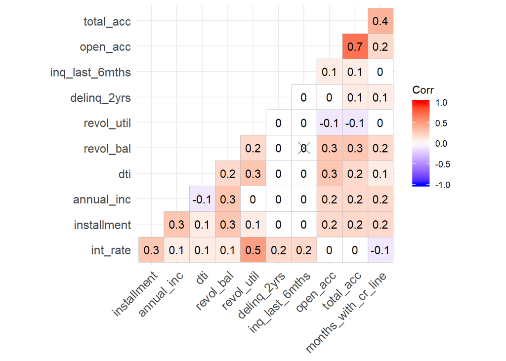

Here we see acceptable correlation scores for each of the variables. Satisfied with this list, we refine our overall data set.

|  | Variable Type |
| --- | --- |
| term.1 | ordered |
| term.2 | factor |
| int_rate | numeric |
| installment | numeric |
| emp_length | factor |
| home_ownership | factor |
| annual_inc | numeric |
| verification_status | factor |
| loan_status | factor |
| purpose | factor |
| addr_state | factor |
| dti | numeric |
| delinq_2yrs | integer |
| inq_last_6mths | integer |
| mths_since_last_delinq | factor |
| open_acc | integer |
| pub_rec | integer |
| revol_bal | numeric |
| revol_util | numeric |
| total_acc | integer |
| repay_fail | integer |
| months_with_cr_line | numeric |

Next, let’s take a look at the distributions for the continuous variables using histograms.

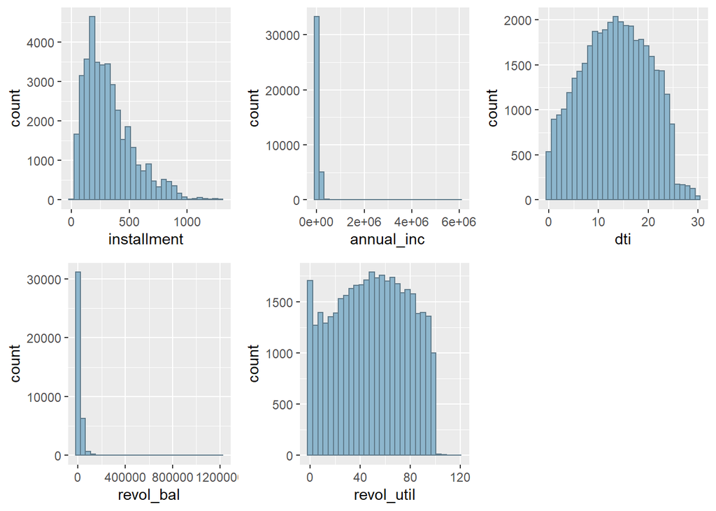

The histograms show some interesting distributions. For variables `installment`, `dti` and `revol_util`, the distributions are approximately normal with some skewing for `installment`. However, some transformation for variables `annual_inc` and `revol_bal` may be required as the majority of the observations are very low with some scattered high values.

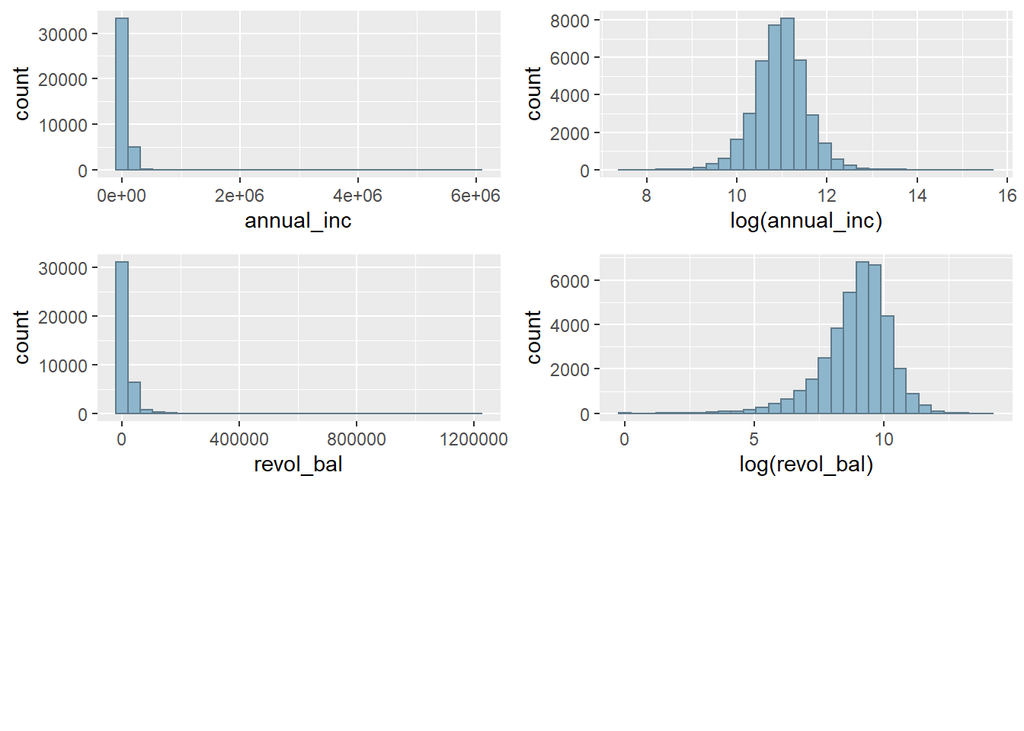

After transforming the two variables, we see a much more normal distribution than we previously saw. Consequently, the transformed version of the variables will be kept for modelling purposes.

It’s important to note that `revol_bal` contained 976 values equal to 0. To fix this, 1 was added to each observation before transformation.

To round off the analysis, binomial GLMs were created for continuous variables not already modelled to understand how the variables relate to the response variable alone. Those include:

```
## =====[1] "repay_fail ~ int_rate"
## # A tibble: 2 x 5
##   term        estimate std.error statistic p.value
##   <chr>          <dbl>     <dbl>     <dbl>   <dbl>
## 1 (Intercept)   -3.68    0.0556      -66.2       0
## 2 int_rate       0.152   0.00396      38.4       0
## AIC 31179
## =====[1] "repay_fail ~ annual_inc_log"
## # A tibble: 2 x 5
##   term           estimate std.error statistic  p.value
##   <chr>             <dbl>     <dbl>     <dbl>    <dbl>
## 1 (Intercept)       1.82     0.276       6.58 4.63e-11
## 2 annual_inc_log   -0.324    0.0253    -12.8  1.75e-37
## AIC 32564
## =====[1] "repay_fail ~ dti"
## # A tibble: 2 x 5
##   term        estimate std.error statistic  p.value
##   <chr>          <dbl>     <dbl>     <dbl>    <dbl>
## 1 (Intercept)  -1.96     0.0328     -59.8  0.
## 2 dti           0.0177   0.00212      8.32 8.91e-17
## AIC 32659
## =====[1] "repay_fail ~ revol_bal"
## # A tibble: 2 x 5
##   term           estimate   std.error statistic  p.value
##   <chr>             <dbl>       <dbl>     <dbl>    <dbl>
## 1 (Intercept) -1.75       0.0166        -105.   0
## 2 revol_bal    0.00000207 0.000000577      3.59 0.000332
## AIC 32716
## =====[1] "repay_fail ~ revol_util"
## # A tibble: 2 x 5
##   term        estimate std.error statistic  p.value
##   <chr>          <dbl>     <dbl>     <dbl>    <dbl>
## 1 (Intercept) -2.21     0.0313       -70.7 0.
## 2 revol_util   0.00948  0.000513      18.5 2.88e-76
## AIC 32380
```

A summary of the output of the models is shown below.

[output not shown]

## Checking linearity

The following section evaluates each continuous variable from the reduced dataset. The behaviours of each variable versus the target variable is plotted to investigate linear relationships between the variable and the logit transformation of our target variable. The following images show the behaviour.

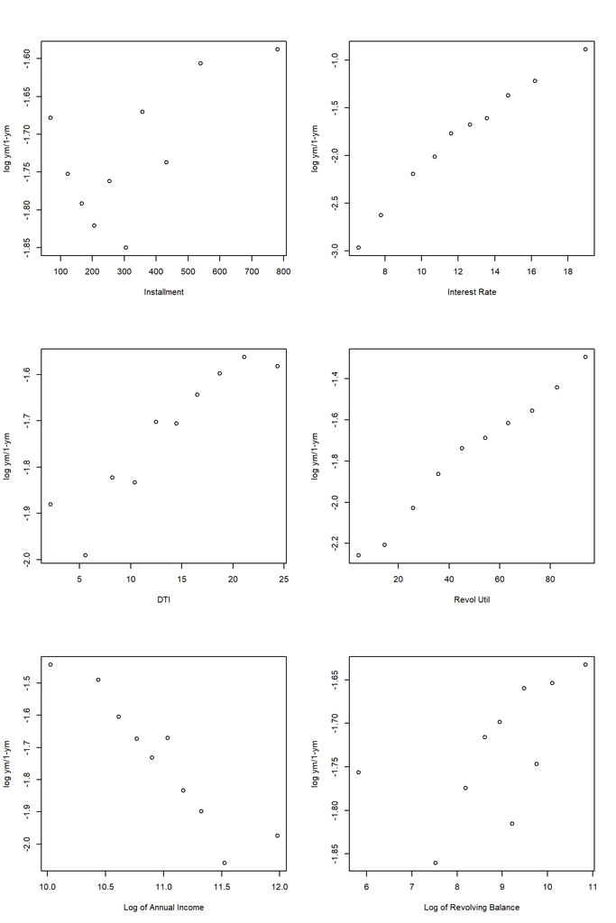

The plots show some obvious trends. For instance:

The variables with a *positive correlation*, that is, as it increases in value so does the rate of repayment failure, are:

- Interest Rate
- DTI
- Revol Util

Installment also appears to have a *positive correlation* with repayment failure however this isn’t so clear for lower installment values.

## Analysis of categorical variables

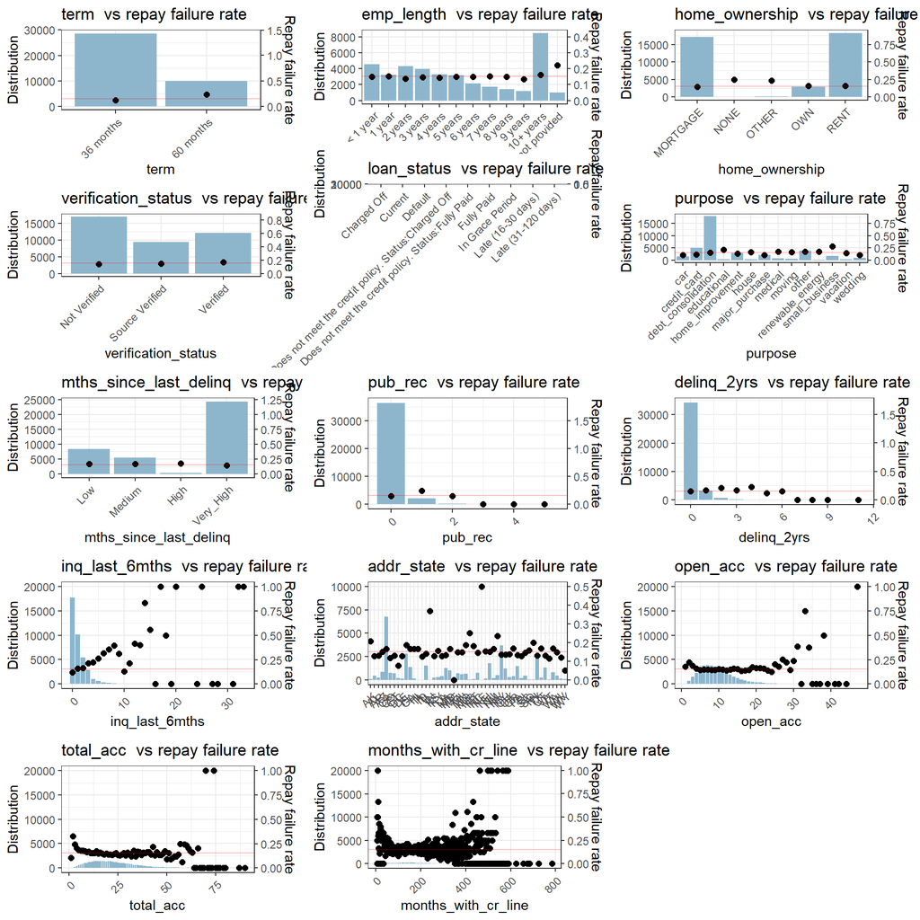

As for the continuous variables, we see that the placement of the dots indicating repayment failure rates is consistent for many of the variables. For instance, `verification_status`, `purpose` and `mths_since_last_delinq` fall into this category. There are some interesting observations to be made about the remaining plots. `term` appears to increase over the two categories, indicating that there are more repayment failures for 60 month term loans than for 36 month term.

For other variables, we see some fluctuation in trends. For example, `home_ownership` appears roughly even except in the none and other categories for which there are very few observations. A similar story is found for some variables involving counts of borrower behaviours. For example, the vast majority of observations for derogatory public records (`pub_rec`) and delinquencies in the last 2 years (`delinq_2yrs`), are for lower counts. For these types of variables, re-grouping (or binning), may provide us with more insight into the repayment failure.

Plots for other variables are more difficult to interpret. For example, repayment failure rates for `inq_last_6mths`, `open_acc` and `total_acc` appear consistent for lower values but then differ widely for larger values. The `addr_state` variable shows a relatively consistent repayment rate across US states with some major exceptions both lower and higher than the average repayment failure rate across the country.

Finally, `loan_status` appears to define the response variable with categories either having a repayment failure rate of 0 or 1. Therefore, its usefulness in the model creation will not be included.

Univariate modelling was performed for the categorical variables to gain an understanding of their goodness of fit against the response variable.

```
## =====[1] "repay_fail ~ term"
## # A tibble: 2 x 5
##   term        estimate std.error statistic   p.value
##   <chr>          <dbl>     <dbl>     <dbl>     <dbl>
## 1 (Intercept)   -1.58     0.0149    -106.  0.
## 2 term.L         0.548    0.0211      26.0 1.07e-148
## AIC 32083
## =====[1] "repay_fail ~ emp_length"
## # A tibble: 12 x 5
##    term                   estimate std.error statistic      p.value
##    <chr>                     <dbl>     <dbl>     <dbl>        <dbl>
##  1 (Intercept)            -1.74       0.0415  -41.9    0
##  2 emp_length1 year        0.0156     0.0642    0.243  0.808
##  3 emp_length2 years      -0.106      0.0609   -1.73   0.0829
##  4 emp_length3 years      -0.0196     0.0613   -0.320  0.749
##  5 emp_length4 years      -0.0422     0.0646   -0.653  0.514
##  6 emp_length5 years       0.00954    0.0648    0.147  0.883
##  7 emp_length6 years      -0.00703    0.0736   -0.0955 0.924
##  8 emp_length7 years       0.0322     0.0791    0.408  0.684
##  9 emp_length8 years       0.00212    0.0847    0.0251 0.980
## 10 emp_length9 years      -0.113      0.0942   -1.20   0.231
## 11 emp_length10+ years     0.0894     0.0510    1.75   0.0797
## 12 emp_lengthnot provided  0.478      0.0871    5.49   0.0000000397
## AIC 32697
## =====[1] "repay_fail ~ home_ownership"
## # A tibble: 5 x 5
##   term                estimate std.error statistic   p.value
##   <chr>                  <dbl>     <dbl>     <dbl>     <dbl>
## 1 (Intercept)           -1.79     0.0218   -82.1   0
## 2 home_ownershipNONE     0.693    1.15       0.600 0.548
## 3 home_ownershipOTHER    0.595    0.213      2.79  0.00523
## 4 home_ownershipOWN      0.103    0.0552     1.86  0.0633
## 5 home_ownershipRENT     0.121    0.0298     4.06  0.0000495
## AIC 32712
## =====[1] "repay_fail ~ verification_status"
## # A tibble: 3 x 5
##   term                               estimate std.error statistic  p.value
##   <chr>                                 <dbl>     <dbl>     <dbl>    <dbl>
## 1 (Intercept)                         -1.80      0.0220    -81.8  0.
## 2 verification_statusSource Verified   0.0489    0.0365      1.34 1.80e- 1
```

[output cut: 73 more lines]

```
## AIC 32727
## =====[1] "repay_fail ~ total_acc"
## # A tibble: 2 x 5
##   term        estimate std.error statistic   p.value
##   <chr>          <dbl>     <dbl>     <dbl>     <dbl>
## 1 (Intercept) -1.61      0.0305     -52.8  0
## 2 total_acc   -0.00504   0.00125     -4.04 0.0000542
## AIC 32712
## =====[1] "repay_fail ~ months_with_cr_line"
## # A tibble: 2 x 5
##   term                 estimate std.error statistic   p.value
##   <chr>                   <dbl>     <dbl>     <dbl>     <dbl>
## 1 (Intercept)         -1.61      0.0317      -50.7  0
## 2 months_with_cr_line -0.000700  0.000176     -3.97 0.0000729
## AIC 32713
```

The following table summarises the AICs for each model generated.

| Variable | AIC |
| --- | --- |
| term | 32083 |
| emp_length | 32697 |
| home_ownership | 32712 |
| verification_status | 32692 |
| purpose | 32399 |
| mths_since_last_delinq | 32681 |
| pub_rec | 32641 |
| delinq_2yrs | 32713 |
| inq_last_6mths | 32318 |
| addr_state | 32661 |
| open_acc | 32727 |
| total_acc | 32712 |
| months_with_cr_line | 32713 |

Many of the models showed coefficients that were not considered significant. In the first instance, these were excluded from the final list of variables unless expert advice contradicted this judgement. The variables excluded here include:

- emp_length
- addr_state

# Feature Selection

Two method were used to identify the features to be used during the modelling process. First step-wise regression using AIC was conducted over the subset of variables. Second, a random forest algorithm was applied to the same set of data and importance scores based on the mean gini was identified.

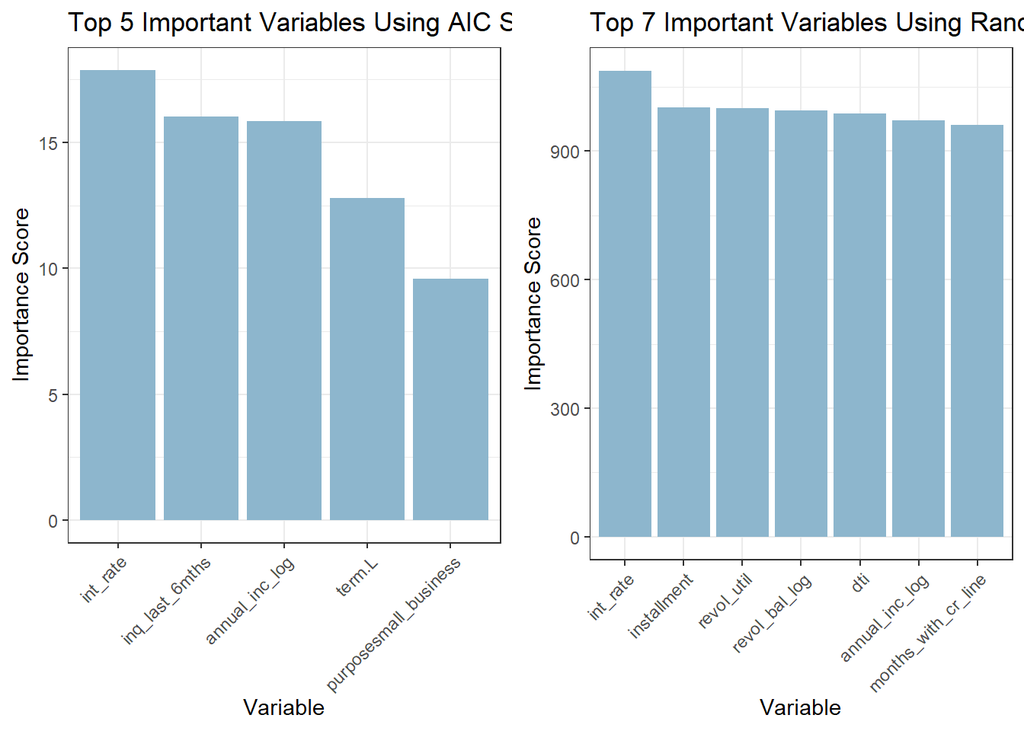

# Modelling

```r
train_data_lst <- split_data(model_df, model_df$repay_fail, train_percent = 0.7)
train_data <- train_data_lst[[1]] #train split
test_data <- train_data_lst[[2]] #test split
summary(train_data)
```

```
##   installment         int_rate            term       inq_last_6mths
##  Min.   :  15.67   Min.   : 5.42   36 months:20048   Min.   : 0.000
##  1st Qu.: 165.67   1st Qu.: 9.63   60 months: 6887   1st Qu.: 0.000
##  Median : 277.32   Median :11.99                     Median : 1.000
##  Mean   : 322.70   Mean   :12.16                     Mean   : 1.086
##  3rd Qu.: 427.55   3rd Qu.:14.72                     3rd Qu.: 2.000
##  Max.   :1305.19   Max.   :24.11                     Max.   :33.000
##
##   home_ownership  annual_inc_log        verification_status
##  MORTGAGE:11917   Min.   : 7.601   Not Verified   :11864
##  NONE    :    4   1st Qu.:10.597   Source Verified: 6590
##  OTHER   :   87   Median :10.982   Verified       : 8481
##  OWN     : 2049   Mean   :10.969
##  RENT    :12878   3rd Qu.:11.314
##                   Max.   :15.176
##
##                purpose           dti        revol_bal_log
##  debt_consolidation:12574   Min.   : 0.00   Min.   : 0.000
##  credit_card       : 3466   1st Qu.: 8.16   1st Qu.: 8.186
##  other             : 2767   Median :13.42   Median : 9.078
##  home_improvement  : 1976   Mean   :13.35   Mean   : 8.689
##  major_purchase    : 1523   3rd Qu.:18.63   3rd Qu.: 9.747
##  small_business    : 1235   Max.   :29.99   Max.   :14.004
##  (Other)           : 3394
##    revol_util     months_with_cr_line  delinq_2yrs
##  Min.   :  0.00   Min.   :  6.0       Min.   : 0.0000
##  1st Qu.: 25.80   1st Qu.:108.0       1st Qu.: 0.0000
##  Median : 49.60   Median :149.0       Median : 0.0000
##  Mean   : 49.07   Mean   :163.7       Mean   : 0.1523
##  3rd Qu.: 72.50   3rd Qu.:203.0       3rd Qu.: 0.0000
##  Max.   :119.00   Max.   :785.0       Max.   :11.0000
##
##  mths_since_last_delinq     emp_length      pub_rec
##  Low      : 5901        10+ years:5864   Min.   :0.00000
##  Medium   : 3817        < 1 year :3272   1st Qu.:0.00000
##  High     :  172        2 years  :2996   Median :0.00000
##  Very_High:17045        3 years  :2772   Mean   :0.05747
##                         4 years  :2295   3rd Qu.:0.00000
##                         1 year   :2288   Max.   :4.00000
##                         (Other)  :7448
##    repay_fail
##  Min.   :0.0000
##  1st Qu.:0.0000
##  Median :0.0000
##  Mean   :0.1521
##  3rd Qu.:0.0000
##  Max.   :1.0000
##
```

At this stage we have arrived at three models.

One derived from a stepAIC function: `int_rate`, `annual_inc_log`, `inq_last_6mths`, `term` and `purpose`

One derived from a random forrest classifier: `int_rate`, `annual_inc_log`, `revol_util`, `installment`, `revol_bal_log`, `dti` and `months_with_cr_line`

One with a combination of all of the rest: `int_rate`, `annual_inc_log`, `inq_last_6mths`, `term`, `purpose`, `revol_util`, `installment`, `revol_bal_log`, `dti` and `months_with_cr_line`.

The Gini scores for the three models are as follows:

```r
#plot the models derived from StepAIC and randforrest and then one with all variables

step_aic_model <- glm(data = train_data, repay_fail ~ int_rate + annual_inc_log + inq_last_6mths + term + purpose, family = binomial("logit"))

rand_forest_model <- glm(data = train_data, repay_fail ~ int_rate + annual_inc_log + revol_util + installment + revol_bal_log + dti + months_with_cr_line , family = binomial("logit"))

all_vars_model <- glm(data = train_data, repay_fail ~ int_rate + annual_inc_log + inq_last_6mths + term + purpose + revol_util + installment + revol_bal_log + dti + months_with_cr_line , family = binomial("logit"))

library(MLmetrics) # for gini function
Gini(y_pred = step_aic_model$fitted.values, y_true = train_data$repay_fail) # 0.3963166
```

```
## [1] 0.3940475
```

```r
Gini(y_pred = rand_forest_model$fitted.values, y_true = train_data$repay_fail) #0.3495213
```

```
## [1] 0.3512784
```

```r
Gini(y_pred = all_vars_model$fitted.values, y_true = train_data$repay_fail) # 0.402305
```

```
## [1] 0.4027635
```

Due to how unbalanced our dataset is we will test the accuracy of our models straight away.

All variable model:

```r
predict <- predict(all_vars_model, newdata= test_data, type = 'response')
table(test_data$repay_fail, predict > 0.5)
```

```
##
##     FALSE TRUE
##   0  9766   47
##   1  1699   31
```

```r
fitted.results <- predict(all_vars_model, newdata= test_data, type='response')
fitted.results <- ifelse(fitted.results > 0.5,1,0)
misClasificError <- mean(fitted.results != test_data$repay_fail)
print(paste('Accuracy',1-misClasificError))
```

```
## [1] "Accuracy 0.848739495798319"
```

StepAIC model:

```r
predict <- predict(step_aic_model, newdata= test_data, type = 'response')
table(test_data$repay_fail, predict > 0.5)
```

```
##
##     FALSE TRUE
##   0  9778   35
##   1  1702   28
```

```r
fitted.results <- predict(step_aic_model, newdata= test_data, type='response')
fitted.results <- ifelse(fitted.results > 0.5,1,0)
misClasificError <- mean(fitted.results != test_data$repay_fail)
print(paste('Accuracy',1-misClasificError))
```

```
## [1] "Accuracy 0.849519189118947"
```

Random Forrest model:

```r
predict <- predict(rand_forest_model, newdata= test_data, type = 'response')
table(test_data$repay_fail, predict > 0.5)
```

```
##
##     FALSE TRUE
##   0  9807    6
##   1  1725    5
```

```r
fitted.results <- predict(rand_forest_model, newdata= test_data, type='response')
fitted.results <- ifelse(fitted.results > 0.5,1,0)
misClasificError <- mean(fitted.results != test_data$repay_fail)
print(paste('Accuracy',1-misClasificError))
```

```
## [1] "Accuracy 0.850038984666031"
```

As a result of previous results, the dataset will be balanced so as to train and test our model more effectively.

```r
#adjusts for the undersampling/oversampling
data_model_fails <- filter(model_df, model_df$repay_fail == "1") #get all fails
data_model_fails<-data_model_fails

data_model_success<-filter(model_df, model_df$repay_fail == "0") # get all sucesses

data_model_random_success <- data_model_success[sample(nrow(data_model_success), nrow(data_model_fails)),] # get a random set of successes

data_model_even <- rbind(data_model_fails, data_model_random_success) #makes a 50/50 dataset
```

```r
#creating the balanced dataset

train_data_lst_bal <- split_data(data_model_even, data_model_even$repay_fail, train_percent = 0.7)
train_data_bal <- train_data_lst_bal[[1]]
test_data_bal <- train_data_lst_bal[[2]]
```

```r
step_aic_model <- glm(data = train_data_bal, repay_fail ~ int_rate + annual_inc_log + inq_last_6mths + term + purpose, family = binomial("logit")) #variables selected from step_aic model

rand_forest_model <- glm(data = train_data_bal, repay_fail ~ int_rate + annual_inc_log + revol_util + installment + revol_bal_log + dti + months_with_cr_line , family = binomial("logit")) #variables selected from random_forrest

all_vars_model <- glm(data = train_data_bal, repay_fail ~ int_rate + annual_inc_log + inq_last_6mths + term + purpose + revol_util + installment + revol_bal_log + dti + months_with_cr_line , family = binomial("logit")) #combination
```

The following are the Gini scores for the balanced dataset using the StepAIC, Random Forrest and All Variable models respectively:

```r
library(MLmetrics) # for gini function
Gini(y_pred = step_aic_model$fitted.values, y_true = train_data_bal$repay_fail) # 0.3823225
```

```
## [1] 0.4043797
```

```r
Gini(y_pred = rand_forest_model$fitted.values, y_true = train_data_bal$repay_fail) # 0.3298934
```

```
## [1] 0.3601092
```

```r
Gini(y_pred = all_vars_model$fitted.values, y_true = train_data_bal$repay_fail) # 0.3881455
```

```
## [1] 0.4100881
```

All variable model:

```r
predict <- predict(all_vars_model, newdata= test_data_bal, type = 'response')
table(test_data_bal$repay_fail, predict > 0.5)
```

```
##
##     FALSE TRUE
##   0  1113  635
##   1   644 1104
```

```r
fitted.results <- predict(all_vars_model, newdata= test_data_bal, type='response')
fitted.results <- ifelse(fitted.results > 0.5,1,0)
misClasificError <- mean(fitted.results != test_data_bal$repay_fail)
print(paste('Accuracy',1-misClasificError))
```

```
## [1] "Accuracy 0.634153318077803"
```

StepAIC model:

```r
predict <- predict(step_aic_model, newdata= test_data_bal, type = 'response')
table(test_data_bal$repay_fail, predict > 0.5)
```

```
##
##     FALSE TRUE
##   0  1128  620
##   1   648 1100
```

```r
fitted.results <- predict(step_aic_model, newdata= test_data_bal, type='response')
fitted.results <- ifelse(fitted.results > 0.5,1,0)
misClasificError <- mean(fitted.results != test_data_bal$repay_fail)
print(paste('Accuracy',1-misClasificError))
```

```
## [1] "Accuracy 0.637299771167048"
```

Random Forest model:

```r
predict <- predict(rand_forest_model, newdata= test_data_bal, type = 'response')
table(test_data_bal$repay_fail, predict > 0.5)
```

```
##
##     FALSE TRUE
##   0  1089  659
##   1   667 1081
```

```r
fitted.results <- predict(rand_forest_model, newdata= test_data_bal, type='response')
fitted.results <- ifelse(fitted.results > 0.5,1,0)
misClasificError <- mean(fitted.results != test_data_bal$repay_fail)
print(paste('Accuracy',1-misClasificError))
```

```
## [1] "Accuracy 0.62070938215103"
```

```r
all_vars_model <- glm(data = train_data_bal, repay_fail ~ int_rate + annual_inc_log + inq_last_6mths + term + purpose + revol_util + installment + revol_bal_log + dti + months_with_cr_line , family = binomial(link = "logit")) #logit combination

all_vars_model_p <- glm(data = train_data_bal, repay_fail ~ int_rate + annual_inc_log + inq_last_6mths + term + purpose + revol_util + installment + revol_bal_log + dti + months_with_cr_line , family = binomial(link = "probit")) #probit combination

all_vars_model_c <- glm(data = train_data_bal, repay_fail ~ int_rate + annual_inc_log + inq_last_6mths + term + purpose + revol_util + installment + revol_bal_log + dti + months_with_cr_line , family = binomial(link = "cloglog")) #cloglog combination
```

The following gini score are for the logit, probit and cloglog links respectively.

```r
library(MLmetrics) # for gini function
Gini(y_pred = all_vars_model$fitted.values, y_true = train_data_bal$repay_fail) # 0.3881455      logit
```

```
## [1] 0.4100881
```

```r
Gini(y_pred = all_vars_model_p$fitted.values, y_true = train_data_bal$repay_fail) #0.3879629     probit
```

```
## [1] 0.4098793
```

```r
Gini(y_pred = all_vars_model_c$fitted.values, y_true = train_data_bal$repay_fail) # 0.3873741    cloglog
```

```
## [1] 0.409068
```

```r
#logit link

predict_final <- predict(all_vars_model, newdata= test_data_bal, type = 'response') #set to predict_final for ROC curve
table(test_data_bal$repay_fail, predict > 0.5)
```

```
##
##     FALSE TRUE
##   0  1089  659
##   1   667 1081
```

```r
fitted.results <- predict(all_vars_model, newdata= test_data_bal, type='response')
fitted.results <- ifelse(fitted.results > 0.5,1,0)
misClasificError <- mean(fitted.results != test_data_bal$repay_fail)
print(paste('Accuracy',1-misClasificError))
```

```
## [1] "Accuracy 0.634153318077803"
```

confustion matrix for the probit link function:

```r
#probit link
predict <- predict(all_vars_model_p, newdata= test_data_bal, type = 'response')
table(test_data_bal$repay_fail, predict > 0.5)
```

```
##
##     FALSE TRUE
##   0  1114  634
##   1   647 1101
```

```r
fitted.results <- predict(all_vars_model_p, newdata= test_data_bal, type='response')
fitted.results <- ifelse(fitted.results > 0.5,1,0)
misClasificError <- mean(fitted.results != test_data_bal$repay_fail)
print(paste('Accuracy',1-misClasificError))
```

```
## [1] "Accuracy 0.63358123569794"
```

confustion matrix for the cloglog link function:

```r
#cloglog link
predict <- predict(all_vars_model_c, newdata= test_data_bal, type = 'response')
table(test_data_bal$repay_fail, predict > 0.5)
```

```
##
##     FALSE TRUE
##   0  1156  592
##   1   694 1054
```

```r
fitted.results <- predict(all_vars_model_c, newdata= test_data_bal, type='response')
fitted.results <- ifelse(fitted.results > 0.5,1,0)
misClasificError <- mean(fitted.results != test_data_bal$repay_fail)
print(paste('Accuracy',1-misClasificError))
```

```
## [1] "Accuracy 0.632151029748284"
```

```r
library("DHARMa") # load residuals
```

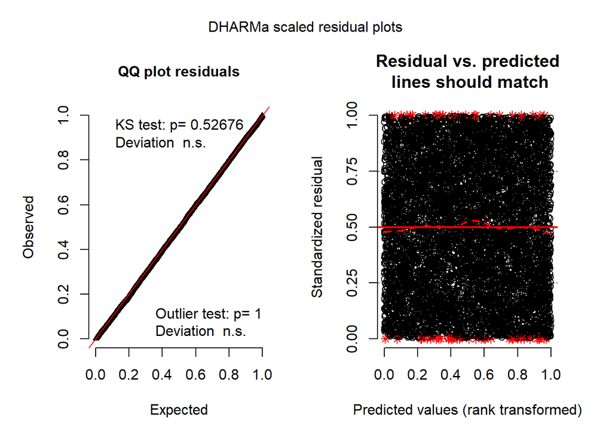

```r
res=simulateResiduals(all_vars_model)
plot(res)
```

```r
# anova(rand_forest_model, test="Chisq") #analyses deviance
```

The QQ plot seems to fit really well. The residuals lack any obvious trend and appear homogeneous. As a result, there is no need to test the other link functions any further

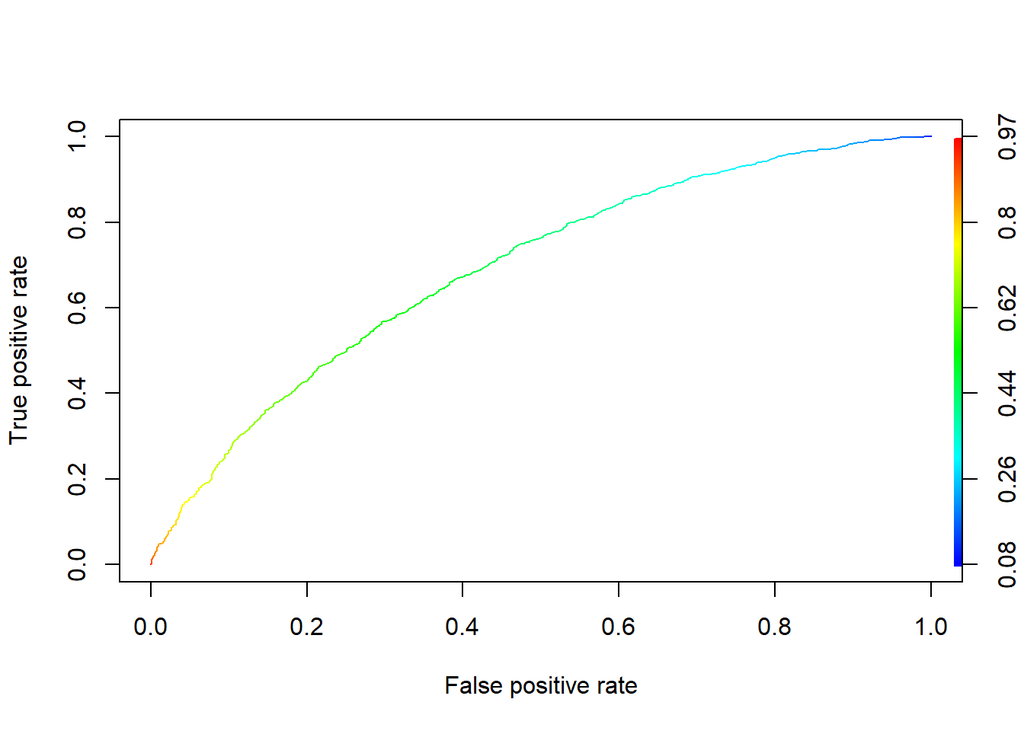

```r
library(ROCR) # for ROC curve
ROCRpred <- prediction(predict_final, test_data_bal$repay_fail)
ROCRperf <- performance(ROCRpred, 'tpr','fpr')
plot(ROCRperf, colorize = TRUE, text.adj = c(-0.2,1.7))
```

Following the previous results, the final model results in R are displayed: below

```r
summary(all_vars_model)
```

```
##
## Call:
## glm(formula = repay_fail ~ int_rate + annual_inc_log + inq_last_6mths +
##     term + purpose + revol_util + installment + revol_bal_log +
##     dti + months_with_cr_line, family = binomial(link = "logit"),
##     data = train_data_bal)
##
## Deviance Residuals:
##    Min      1Q  Median      3Q     Max
## -2.265  -1.046  -0.107   1.068   2.088
##
## Coefficients:
##                             Estimate Std. Error z value Pr(>|z|)
## (Intercept)                3.9991433  0.5507026   7.262 3.82e-13 ***
## int_rate                   0.1129277  0.0090561  12.470  < 2e-16 ***
## annual_inc_log            -0.5746414  0.0517271 -11.109  < 2e-16 ***
## inq_last_6mths             0.1513542  0.0161510   9.371  < 2e-16 ***
## term.L                     0.3602180  0.0419662   8.584  < 2e-16 ***
## purposecredit_card         0.0021089  0.1472116   0.014 0.988570
## purposedebt_consolidation  0.2209348  0.1340408   1.648 0.099298 .
## purposeeducational         0.4046201  0.2630578   1.538 0.124014
## purposehome_improvement    0.2957841  0.1555473   1.902 0.057227 .
## purposehouse               0.2405708  0.2614144   0.920 0.357434
## purposemajor_purchase      0.1221944  0.1702281   0.718 0.472864
## purposemedical             0.6036047  0.2184602   2.763 0.005727 **
## purposemoving              0.3994887  0.2206038   1.811 0.070158 .
## purposeother               0.5178236  0.1465352   3.534 0.000410 ***
## purposerenewable_energy    1.0318357  0.5176998   1.993 0.046249 *
## purposesmall_business      1.0116704  0.1639746   6.170 6.84e-10 ***
## purposevacation            0.4287789  0.2911170   1.473 0.140785
## purposewedding            -0.1396046  0.2000320  -0.698 0.485232
## revol_util                 0.0057468  0.0011635   4.939 7.84e-07 ***
## installment                0.0004660  0.0001394   3.342 0.000833 ***
## revol_bal_log             -0.0205223  0.0159587  -1.286 0.198457
## dti                        0.0062888  0.0038317   1.641 0.100746
## months_with_cr_line        0.0006574  0.0003172   2.073 0.038198 *
## ---
## Signif. codes:  0 '***' 0.001 '**' 0.01 '*' 0.05 '.' 0.1 ' ' 1
##
## (Dispersion parameter for binomial family taken to be 1)
##
##     Null deviance: 11312  on 8159  degrees of freedom
## Residual deviance: 10215  on 8137  degrees of freedom
## AIC: 10261
##
## Number of Fisher Scoring iterations: 4
```

# Findings